# Problem Set 4

Author

Ludovico Sinigaglia

Published

November 20, 2026

**GitHub repo:** https://github.com/ludsin/ec422_ps4_sinigaglia

## ARIMA vs. ETS

### 2.1 - The Data

```r
library(tidyverse)
library(fpp3)

liquor_raw <- read_csv(
  "data/MRTSSM4453USN.csv",
  na = ".",
  col_types = cols(
    observation_date = col_date(format = "%Y-%m-%d"),
    MRTSSM4453USN = col_double()
  )
)

liquor <- liquor_raw |>
  transmute(
    Month = yearmonth(observation_date),
    sales = MRTSSM4453USN
  ) |>
  as_tsibble(index = Month) |>
  filter(Month <= yearmonth("2019 Dec"))

has_gaps(liquor)
```

```
# A tibble: 1 × 1
  .gaps
  <lgl>
1 FALSE
```

### 2.1b - Sales and Seasonal Patterns

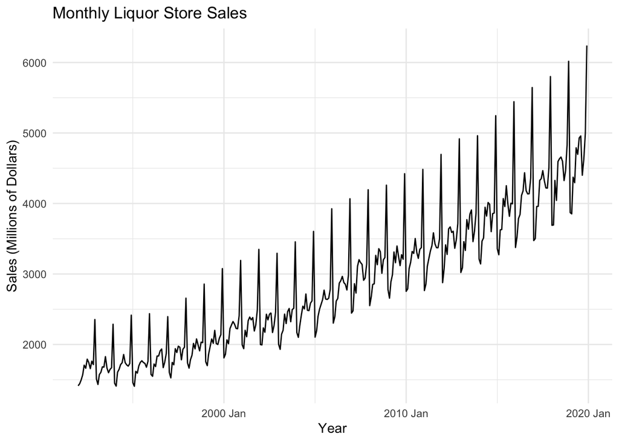

```r
liquor |>
  autoplot(sales) +
  labs(
    title = "Monthly Liquor Store Sales",
    x = "Year",
    y = "Sales (Millions of Dollars)"
  ) +
  theme_minimal()
```

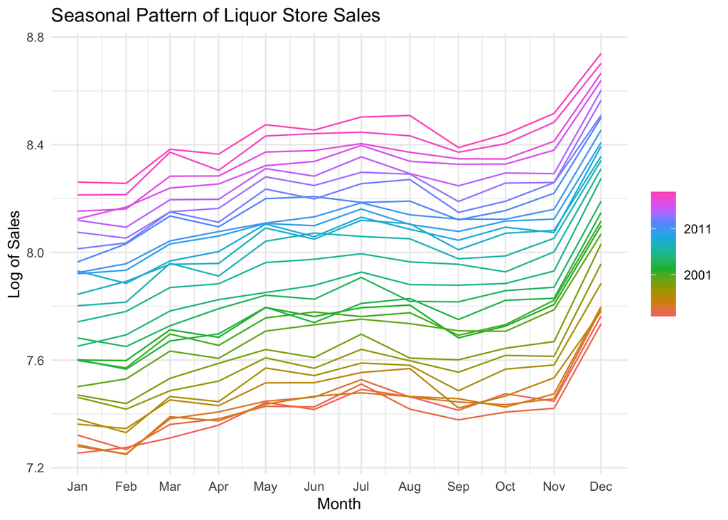

```r
liquor |>
  gg_season(log(sales)) +
  labs(
    title = "Seasonal Pattern of Liquor Store Sales",
    x = "Month",
    y = "Log of Sales"
  ) +
  theme_minimal()
```

Looking at the first graph, liquor store sales have generally increased over time, especially in the later years. There is also a clear seasonal pattern. December has the highest sales, probably because of the holidays, while February tends to have the lowest sales.

The seasonal changes also seem to get bigger as overall sales increase. This suggests that the seasonal pattern depends on the level of sales. Using logs makes sense because it helps make these fluctuations more stable over time.

### 2.2a - ARIMA and ETS Models

```r
liquor_fit <- liquor |>
  model(
    arima = ARIMA(log(sales)),
    ets = ETS(log(sales))
  )

liquor_fit |>
  select(arima) |>
  report()
```

```
Series: sales
Model: ARIMA(1,0,2)(2,1,1)[12] w/ drift
Transformation: log(sales)

Coefficients:
         ar1      ma1     ma2    sar1     sar2     sma1  constant
      0.8948  -0.7374  0.2477  0.3679  -0.2334  -0.8845    0.0036
s.e.  0.0355   0.0697  0.0623  0.0668   0.0665   0.0468    0.0001

sigma^2 estimated as 0.0005469:  log likelihood=752.43
AIC=-1488.85   AICc=-1488.4   BIC=-1458.61
```

```r
liquor_fit |>
  select(ets) |>
  report()
```

```
Series: sales
Model: ETS(A,A,A)
Transformation: log(sales)
  Smoothing parameters:
    alpha = 0.3296099
    beta  = 0.007560263
    gamma = 0.0001765132

  Initial states:
     l[0]         b[0]      s[0]      s[-1]        s[-2]       s[-3]      s[-4]
 7.412219 0.0007608238 0.3263441 0.03153301 -0.004849389 -0.03530501 0.02512163
      s[-5]      s[-6]      s[-7]       s[-8]      s[-9]     s[-10]     s[-11]
 0.05558624 0.01219515 0.02503206 -0.06088935 -0.0607952 -0.1578065 -0.1561667

  sigma^2:  7e-04

      AIC      AICc       BIC
-489.1517 -487.2272 -424.2608
```

The ARIMA model selected was ARIMA(1,0,2)(2,1,1)[12] with drift. It doesn’t use regular differencing, but it does use one seasonal difference over 12 months. This makes sense because the sales data have a strong yearly seasonal pattern. The model also includes a drift term to account for the general upward trend.

For ETS, the selected model was ETS(A,A,A). This means it has additive errors, an additive trend, and additive seasonality. Since the model uses log sales, the seasonal changes are modeled on the log scale.

### 2.2b - Checking ARIMA Residuals

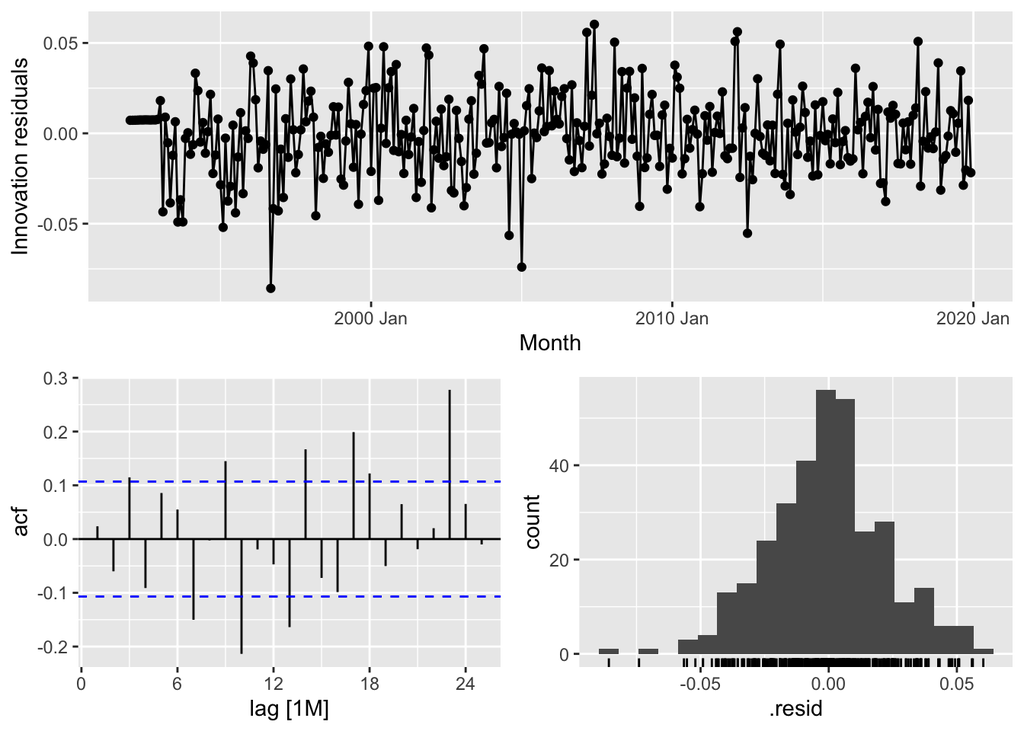

```r
liquor_fit |>
  select(arima) |>
  gg_tsresiduals()
```

```r
liquor_fit |>
  select(arima) |>
  augment() |>
  features(.innov, ljung_box, lag = 24, dof = 6)
```

```
# A tibble: 1 × 3
  .model lb_stat lb_pvalue
  <chr>    <dbl>     <dbl>
1 arima     120.         0
```

The residuals are mostly centered around zero, but the ACF plot shows some significant spikes, so there is still some autocorrelation left in the data. The Ljung-Box test gives a statistic of about 120 and a p-value close to zero. This means we reject the null hypothesis, and the residuals do not appear to be white noise. However, this does not necessarily mean the model will forecast poorly. We still need to compare its forecasting accuracy against the other models.

### 2.3 - Forecasting Horse Race

#### 2.3a - Forecast Origins

The cross-validation uses 216 forecast origins. The first forecast is for January 2002, and the last one is for December 2019. The training sample starts with 120 months and increases by one month each time.

#### 2.3b - Forecast Accuracy

```r
liquor_accuracy <- readRDS("results/liquor_accuracy.rds")

liquor_accuracy |>
  select(.model, RMSE, MAE) |>
  knitr::kable(digits = 1)
```

| .model | RMSE | MAE |
| --- | --- | --- |
| arima | 81.4 | 65.7 |
| ets | 94.4 | 72.3 |
| snaive | 161.3 | 136.6 |

ARIMA has the lowest RMSE (81.4) and MAE (65.7), so it performs the best out of the three models. ETS comes second, while the seasonal naive model has the largest errors. Both RMSE and MAE give the same ranking, which makes ARIMA the best choice based on these results.

### 2.4 - Diebold-Mariano Tests

```r
dm_arima_ets <- readRDS("results/dm_arima_ets.rds")
dm_arima_snaive <- readRDS("results/dm_arima_snaive.rds")

dm_arima_ets
```

```
    Diebold-Mariano Test

data:  liquor_errs$arimaliquor_errs$ets
DM = -2.9062, Forecast horizon = 1, Loss function power = 2, p-value =
0.004042
alternative hypothesis: two.sided
```

```r
dm_arima_snaive
```

```
    Diebold-Mariano Test

data:  liquor_errs$arimaliquor_errs$snaive
DM = -10.755, Forecast horizon = 1, Loss function power = 2, p-value <
2.2e-16
alternative hypothesis: two.sided
```

Both DM tests show statistically significant differences in forecasting accuracy. The ARIMA vs. ETS test has a statistic of -2.9062 and a p-value of 0.004042, while the ARIMA vs. seasonal naive test has a statistic of -10.755 and a p-value below 2.2e-16. Since ARIMA also has the lowest RMSE and MAE, I would choose it for the liquor store chain because it gave the most accurate forecasts in this comparison.